# Project: Identify Customer Segments

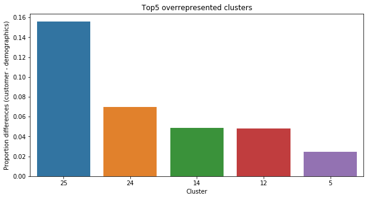

```python
# Overrepresented clusters in customers dataset:

overrepresented_clusters = proportion_differences[proportion_differences > 0].sort_values(ascending=False)

# Plot top5 overrepresented clusters:
plt.figure(figsize=[10,5])
sns.barplot(x=overrepresented_clusters.index[:5], y=overrepresented_clusters.values[:5], order=overrepresented_clusters.index[:5])
plt.xlabel("Cluster")
plt.ylabel("Proportion differences (customer - demographics)")
plt.title("Top5 overrepresented clusters")
plt.show()
```

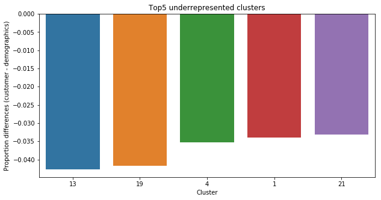

```python
# Underrepresented clusters in customers dataset:

underrepresented_clusters = proportion_differences[proportion_differences < 0].sort_values()

# Plot top5 underrepresented clusters:
plt.figure(figsize=[10,5])
sns.barplot(x=underrepresented_clusters.index[:5], y=underrepresented_clusters.values[:5], order=underrepresented_clusters.index[:5])
plt.xlabel("Cluster")
plt.ylabel("Proportion differences (customer - demographics)")
plt.title("Top5 underrepresented clusters")
plt.show()
```

```python
# Features to be checked inside the clusters:
check_features = ["HH_EINKOMMEN_SCORE",
                  "CAMEO_INTL_2015_wealth",
                  "MOBI_REGIO",
                  "KBA05_ANTG1",
                  "ALTERSKATEGORIE_GROB",
                  "ANREDE_KZ"]
```

```python
# Define function for inverse transformation and plotting the distribution of selected features:
def plot_cluster_features(cluster, features_pca, labels, features):
    inverse_standardized_features = pca.inverse_transform(features_pca[labels == cluster])
    inverse_features = scaler.inverse_transform(inverse_standardized_features)

    inverse_features = pd.DataFrame(np.round(inverse_features), columns=azdias_few_missing.columns)

    print("Feature distributions in cluster {}".format(cluster))

    fig = plt.figure(figsize=[20, 10])

    for feature, n in zip(features, range(len(features))):
        ax = fig.add_subplot(2,3,n+1)
        sns.countplot(inverse_features[feature])
        plt.tight_layout()

    plt.show()
```

```
Feature distributions in cluster 24
```

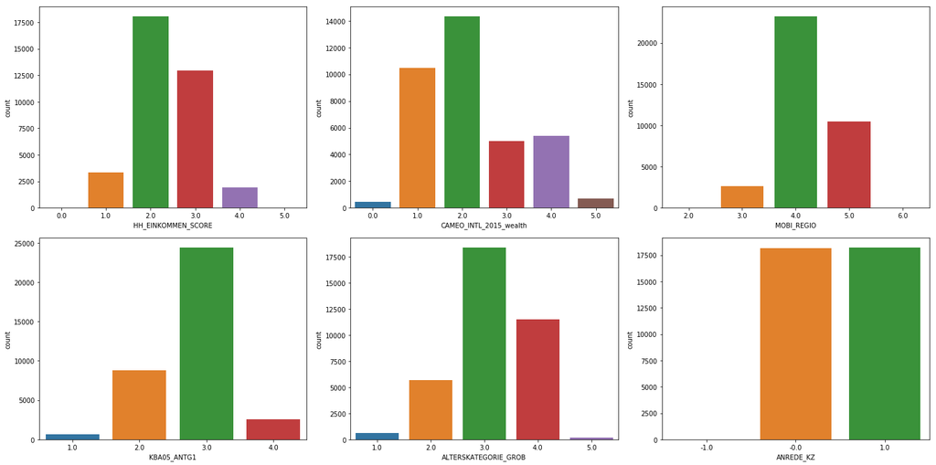

```python
# What kinds of people are part of a cluster that is overrepresented in the
# customer data compared to the general population?
# Let's have a look at cluster 24:
plot_cluster_features(cluster=24, features_pca=features_pca, labels=labels, features=check_features)
```

```
Feature distributions in cluster 13
```

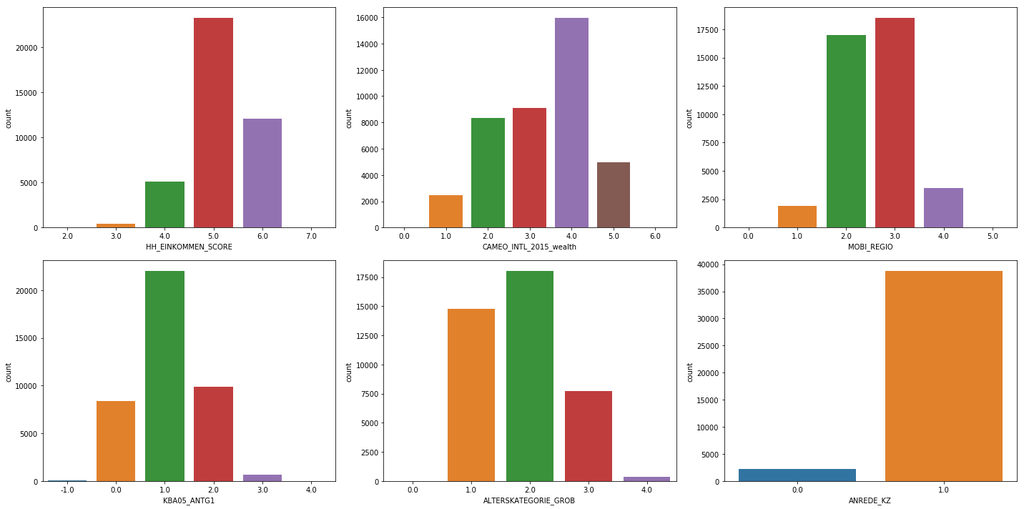

```python
# What kinds of people are part of a cluster that is underrepresented in the
# customer data compared to the general population?
# Let's have a look at cluster 13:
plot_cluster_features(cluster=13, features_pca=features_pca, labels=labels, features=check_features)
```

### Discussion 3.3: Compare Customer Data to Demographics Data

In check_features I decided to put those features, which are ordinal and had the highest weights in the principal components shown at Step 2.3, plus the gender. I chose the inverse transformation method to get the original distributions of the chosen features.

Since the most overrepresented cluster in customers dataset was the one with many missing values, I decided to check the second most overrepresented cluster (24) and it seems that it is neutral from gender perspective. People, who mostly not have 1-2 family houses, who have higher income, live in wealthy households, who are mostly older than 46 years and are not likely to move, are relatively popular targets of the company.

The most underrepresented cluster is 13. People who are relatively unpopular targets of the company are mostly females, below 45 years with lower income, living in poorer households and not in 1-2 family houses, but they are more likely to move.

> Congratulations on making it this far in the project! Before you finish, make sure to check through the entire notebook from top to bottom to make sure that your analysis follows a logical flow and all of your findings are documented in **Discussion** cells. Once you've checked over all of your work, you should export the notebook as an HTML document to submit for evaluation. You can do this from the menu, navigating to **File -> Download as -> HTML (.html)**. You will submit both that document and this notebook for your project submission.